# blatt04

Seyed Ramtin Hosseini

2025-01-08

# Arbeitsblatt 04

## Aufgabe 1

In meinem Analyseprojekt beschäftige ich mich mit der Untersuchung von Erwerbssituation und Arbeitsmarkttrends in Deutschland sowie drei weiteren EU-Mitgliedsstaaten: Frankreich, Italien und Polen. Dabei verwende ich Daten aus den Jahren 2008 bis 2022, um zeitliche Entwicklungen und regionale Unterschiede zu beleuchten. Mein Fokus liegt auf der Analyse der Auswirkungen von Bildungsniveau, Alter und Geschlecht auf die Beschäftigungsquote und Arbeitslosigkeit, wobei folgende drei Forschungsfragen im Mittelpunkt stehen:

1. **Bildungsniveau und Arbeitsmarktchancen:** Wie ist die Erwerbssituation in Deutschland im Hinblick auf das Bildungsniveau im Vergleich zu Frankreich, Italien und Polen? Haben Menschen mit höherer Bildung bessere Chancen auf dem Arbeitsmarkt, sowohl in Deutschland als auch in den anderen Ländern?
2. **Alter und Erwerbssituation:** Wie hat sich die Erwerbssituation älterer Menschen in Deutschland zwischen 2008 und 2022 verändert, und wie steht dies im Vergleich zu den anderen Ländern? Arbeiten heute mehr ältere Menschen als früher?
3. **Geschlechterunterschiede:** In welchem der untersuchten Länder ist der Unterschied in der Beschäftigungsquote zwischen Frauen und Männern am geringsten, und wie hat sich dieser entwickelt?

Die Entscheidung für diese Fragestellungen ergibt sich aus ihrer Relevanz für Gesellschaft, Politik und Wirtschaft. Die Arbeitsmarktsituation ist ein zentraler Indikator für die Lebensqualität und den sozialen Fortschritt in einer Gesellschaft. Der Vergleich verschiedener Altersgruppen, Geschlechter und Bildungsniveaus bietet wertvolle Einblicke, um bestehende Herausforderungen wie Ungleichheiten oder Altersdiskriminierung aufzuzeigen. Zielgruppen dieser Analyse sind daher politische Entscheidungsträger, Arbeitsmarktanalysten sowie alle, die sich für soziale Gerechtigkeit und wirtschaftliche Entwicklungen in der EU interessieren.

Ich habe mich dazu entschieden, mit einem neuen Datensatz zu arbeiten, da dieser detailliertere und umfassendere Informationen bietet, die eine tiefere und anspruchsvollere Analyse ermöglichen. Dies macht die Ergebnisse nicht nur relevanter, sondern eröffnet auch die Möglichkeit, differenzierte Erkenntnisse für die genannten Forschungsfragen zu gewinnen.

## Aufgabe 2

Der “Current well-being”-Datensatz der OECD umfasst mehr als 80 Indikatoren, die auf dem OECD-Wohlbefindens-Dashboard basieren. Diese Indikatoren sind in 11 Dimensionen des aktuellen Wohlbefindens unterteilt, die materielle Bedingungen (z.B. Einkommen, Vermögen, Arbeit), Lebensqualitätsfaktoren (z.B. Gesundheit, Bildung, Umweltqualität), sowie soziale und zwischenmenschliche Faktoren (z.B. soziale Kontakte, Bürgerengagement) abdecken. Die Beobachtungseinheit in diesem Datensatz ist in der Regel das Land, wobei die Daten durch demografische Merkmale wie Geschlecht, Alter, Bildungsniveau und weitere relevante Faktoren differenziert werden. Die Erhebung der Daten erfolgt durch nationale statistische Institute und Organisationen in Zusammenarbeit mit der OECD, wobei moderne statistische Methoden zur Sammlung und Analyse der Informationen eingesetzt werden, um länderübergreifende Vergleiche und Analysen zu ermöglichen.

Untersuchungseinheit: Land

Quelle: OECD (Current Well-being)

Anzahl der Reihen: 89712

Anzahl der Spalten: 30

### Data Wrangling

In dieser Analyse wird der Datensatz aufbereitet, sodass er für die Forschungsfragen geeignet ist. Dabei folgen wir strukturierten Schritten, um den Datensatz zu bereinigen, relevante Informationen auszuwählen und in ein analysierbares Format zu bringen. Jeder Schritt wird klar erläutert, und unnötige Schritte werden vermieden.

### Installieren und Laden der benötigten Pakete

Das `tidyverse`-Paket wird verwendet, da es eine Sammlung von Werkzeugen für Datenmanipulation, Visualisierung und Analyse bietet.

```r
#install.packages("tidyverse")
```

Laden des tidyverse-Pakets

```r
library(tidyverse)
```

Laden des Datensatzes Der Datensatz wird aus einer CSV-Datei geladen. Er enthält Informationen zu verschiedenen Ländern, Messungen, Geschlechtern und Bildungsniveaus.

```r
current_wellbeing <- read_csv("data/OECD.WISE.WDP,DSD_HSL@DF_HSL_CWB,+all.csv")
```

Datenüberblick: Struktur und Dimensionen Zunächst wird die Struktur des Datensatzes untersucht, um die Anzahl der Spalten und Reihen zu bestimmen.

Anzahl der Spalten

```r
current_wellbeing %>% ncol()
```

```
## [1] 30
```

Anzahl der Reihen

```r
current_wellbeing %>% nrow()
```

```
## [1] 89712
```

### Auswahl relevanter Variablen

Für die Analyse werden nur die folgenden Spalten benötigt:

- `Reference area`: Land
- `Measure`: Messung (z. B. Beschäftigungsquote)
- `Age`: Altersgruppe
- `Sex`: Geschlecht
- `Education level`: Bildungsniveau
- `TIME_PERIOD`: Jahr
- `OBS_VALUE`: Beobachteter Wert

```r
current_wellbeing_selected <- current_wellbeing %>% select(`Reference area`,Measure,Age,Sex,`Education level`,TIME_PERIOD,OBS_VALUE)
```

### Filtern der relevanten Länder

Es werden nur die Länder **Deutschland**, **Frankreich**, **Italien** und **Polen** für die Analyse berücksichtigt.

```r
current_wellbeing_filteredByCountry <- current_wellbeing_selected %>% filter(
                                                                              `Reference area`=="Germany" | `Reference area`=="France" | `Reference area`=="Italy" | `Reference area`=="Poland"
)
```

### Auswahl relevanter Messungen

Für die Forschungsfragen sind nur die folgenden Messungen relevant:

- **Employment rate** (Beschäftigungsquote)
- **Long-term unemployment rate** (Langzeitarbeitslosenquote)

```r
current_well_being_filteredByMeasure <- current_wellbeing_filteredByCountry %>% filter(Measure=="Long-term unemployment rate" | Measure=="Employment rate")
```

### Filtern des Zeitraums

Die Analyse beschränkt sich auf die Jahre **2008 bis 2022**. Alle anderen Zeitpunkte werden ausgeschlossen.

```r
current_well_being_filteredByYear <- current_well_being_filteredByMeasure %>% filter(TIME_PERIOD>2007 &TIME_PERIOD<2023)
```

### Umstrukturierung der Daten (Pivoting)

Der Datensatz wird von einem langen Format in ein breites Format umgewandelt, sodass jede Messung (Beschäftigungsquote und Langzeitarbeitslosenquote) in einer eigenen Spalte dargestellt wird. Dies erleichtert die Analyse.

```r
current_well_being_wider <- current_well_being_filteredByYear %>% pivot_wider(names_from = Measure, values_from = OBS_VALUE)
```

### Umgang mit fehlenden Werten

Fehlende Werte (`NA`) werden durch den Mittelwert der jeweiligen Spalte ersetzt, um eine vollständige Analyse zu ermöglichen.

```r
current_well_being_NoMissingValue <- current_well_being_wider %>% mutate(across(where(is.numeric), ~ ifelse(is.na(.), mean(., na.rm = TRUE), .)))
```

### Übersetzung der Variablennamen ins Deutsche

Die Variablennamen werden ins Deutsche übersetzt, um die Verständlichkeit für die Zielgruppe zu erhöhen.

```r
current_well_being_germanVaribales <- current_well_being_NoMissingValue %>%
  rename(
    Referenzgebiet = `Reference area`,
    Alter = Age,
    Geschlecht = Sex,
    Bildungsniveau = `Education level`,
    Zeitraum = TIME_PERIOD,
    Beschäftigungsquote = `Employment rate`,
    Langzeitarbeitslosenquote = `Long-term unemployment rate`
  )
```

### Übersetzung der Werte ins Deutsche

Auch die Werte innerhalb der Variablen werden ins Deutsche übersetzt.

```r
current_well_being_german <- current_well_being_germanVaribales %>%  mutate(
  Referenzgebiet = recode(Referenzgebiet,
                      "Germany" = "Deutschland",
                      "Italy" = "Italien",
                      "France" = "Frankreich",
                      "Poland" = "Polen"),

   Geschlecht= recode(Geschlecht,
                      "Total" = "Gesamt",
                      "Female" = "Weiblich",
                      "Male" = "Männlich"),

  Bildungsniveau = recode(Bildungsniveau,
                          "Total" = "Gesamt",
                          "Primary education" = "Primärbildung",
                          "Secondary education" = "Sekundärbildung",
                          "Tertiary education" = "Tertiärbildung"),
  Alter = recode(Alter,
                 "Total" = "Gesamt",
                 "Young" = "Jung",
                 "Old" = "Alt",
                 "Middle-aged" = "Mittelalter")
)
```

### Finales Ergebnis

Nach diesen Schritten ist der Datensatz vollständig bereinigt, übersetzt und in einem breiten Format, das sich für die Analyse eignet.

```r
current_well_being_clean <- current_well_being_german
head(current_well_being_clean, n=10)
```

```
## # A tibble: 10 × 7
##    Referenzgebiet Alter  Geschlecht Bildungsniveau Zeitraum Beschäftigungsquote
##    <chr>          <chr>  <chr>      <chr>             <dbl>               <dbl>
##  1 Deutschland    Gesamt Gesamt     Primärbildung      2008                55.3
##  2 Deutschland    Gesamt Gesamt     Primärbildung      2009                54.9
##  3 Deutschland    Gesamt Gesamt     Primärbildung      2010                55.3
##  4 Deutschland    Gesamt Gesamt     Primärbildung      2011                56.5
##  5 Deutschland    Gesamt Gesamt     Primärbildung      2012                57.5
##  6 Deutschland    Gesamt Gesamt     Primärbildung      2013                57.9
##  7 Deutschland    Gesamt Gesamt     Primärbildung      2014                58.0
##  8 Deutschland    Gesamt Gesamt     Primärbildung      2015                58.7
##  9 Deutschland    Gesamt Gesamt     Primärbildung      2016                59.4
## 10 Deutschland    Gesamt Gesamt     Primärbildung      2017                60.0
## # ℹ 1 more variable: Langzeitarbeitslosenquote <dbl>
```

Durch diesen Data-Wrangling-Prozess wurden die relevanten Variablen und Werte ausgewählt, der Datensatz bereinigt und fehlende Werte behandelt. Die Daten sind nun übersichtlich, gut strukturiert und bereit für die Beantwortung der Forschungsfragen. Unnötige Schritte, wie das Entfernen von weiteren Kategorien oder tiefere statistische Transformationen, waren nicht erforderlich, da die Daten bereits gut strukturiert vorlagen.

## Aufgabe 3

Plot 1

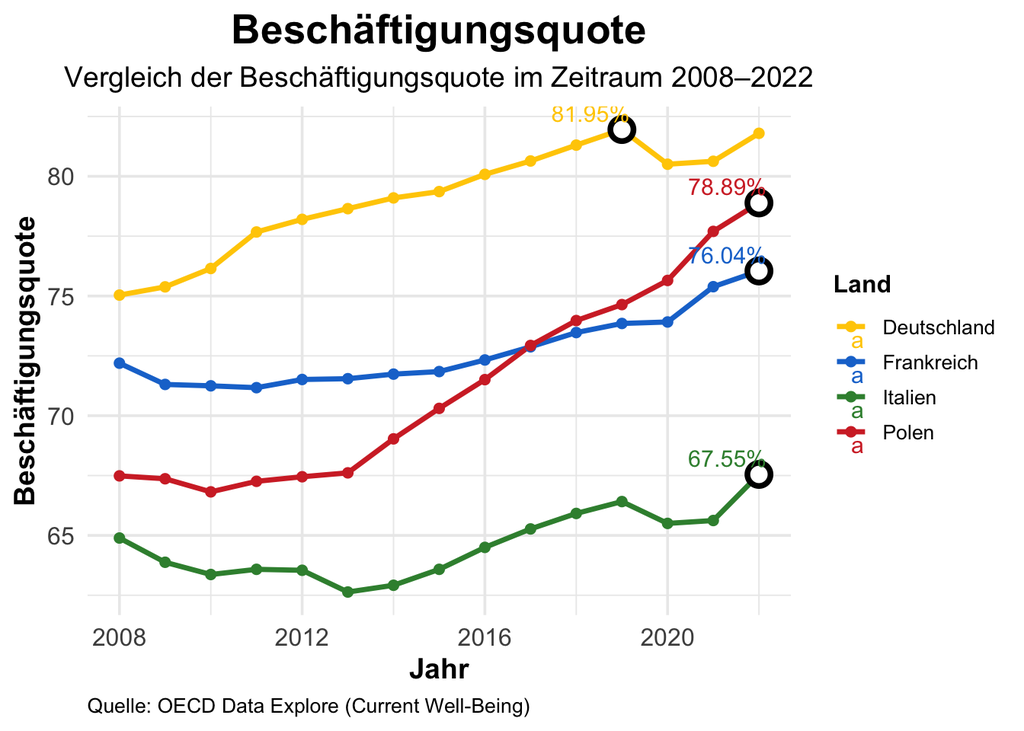

```r
## Beschäftigungsquote
current_well_being_german %>%
  filter(Alter %in% "Gesamt") %>%
  filter(Geschlecht %in% "Gesamt") %>%
  filter(Bildungsniveau == "Gesamt") %>%
  ggplot() +
  aes(x = Zeitraum, y = Beschäftigungsquote, color = Referenzgebiet, group = Referenzgebiet) +
  geom_line(size = 1.2) +  # Thick lines to emphasize trends
  geom_point(size = 2) +  # Highlight data points
  scale_color_manual(
    values = c("Deutschland" = "#FFCC00",
               "Polen" = "#D32F2F",
               "Italien" = "#388E3C",
               "Frankreich" = "#1976D2")
  ) +
  labs(
    x = "Jahr",
    y = "Beschäftigungsquote",
    title = "Beschäftigungsquote",
    subtitle = "Vergleich der Beschäftigungsquote im Zeitraum 2008–2022",
    caption = "Quelle: OECD Data Explore (Current Well-Being)",
    color = "Land"
  ) +
  theme_minimal(base_size = 14) +
  theme(
    plot.title = element_text(size = 20, face = "bold", hjust = 0.5),
    plot.subtitle = element_text(size = 14, hjust = 0.5),
    plot.caption = element_text(size = 10, hjust = 0),
    axis.title.y = element_text(size = 14, face = "bold"),
    axis.title.x = element_text(size = 14, face = "bold"),
    axis.text = element_text(size = 12),
    legend.position = "right",
    legend.title = element_text(size = 12, face = "bold"),
    legend.text = element_text(size = 10)
  ) +
  # Add points at the maximum value of each line
  geom_point(
    data = current_well_being_german %>%
      filter(Alter %in% "Gesamt") %>%
      filter(Geschlecht %in% "Gesamt") %>%
      filter(Bildungsniveau == "Gesamt") %>%
      filter(Zeitraum >= 2008L & Zeitraum <= 2022L) %>%
      group_by(Referenzgebiet) %>%
      filter(Beschäftigungsquote == max(Beschäftigungsquote, na.rm = TRUE)) %>%
      ungroup(),
    aes(x = Zeitraum, y = Beschäftigungsquote),
    size = 4, shape = 21, fill = "white", color = "black", stroke = 2  # Highlight max point
  ) +
  # Add labels for the maximum values (year and value)
  geom_text(
    data = current_well_being_german %>%
      filter(Alter %in% "Gesamt") %>%
      filter(Geschlecht %in% "Gesamt") %>%
      filter(Bildungsniveau == "Gesamt") %>%
      filter(Zeitraum >= 2008L & Zeitraum <= 2022L) %>%
      group_by(Referenzgebiet) %>%
      filter(Beschäftigungsquote == max(Beschäftigungsquote, na.rm = TRUE)) %>%
      ungroup(),
    aes(x = Zeitraum, y = Beschäftigungsquote, label = paste0(round(Beschäftigungsquote, 2), "%")),
    size = 4, vjust = -0.5, hjust = 0.9
  )
```